# AdultsCensus-Sklearn

### Experiment with Sklearn classification models

- use Adult Census dataset from UCI Machine Learning Repository
- preprocess, clean, and explore the dataset
- perform numerous experiements with sklearn classifiers to predict those $50K or greater income
- tune models using grid search
- record experiments in csv
- analyze results

```python
import numpy as np
import pandas as pd
import matplotlib as mpl
import matplotlib.pyplot as plt
import time
import random

# Regression
from sklearn.linear_model import LinearRegression
from sklearn.linear_model import Ridge
from sklearn.linear_model import Lasso
from sklearn.linear_model import ElasticNet
from sklearn.linear_model import SGDClassifier

# Classification
from sklearn.neighbors import KNeighborsClassifier
from sklearn.tree import DecisionTreeClassifier
from sklearn.svm import LinearSVC
from sklearn.svm import SVC

# Ensembles
from sklearn.ensemble import RandomForestClassifier
from sklearn.ensemble import GradientBoostingClassifier
from sklearn.ensemble import AdaBoostClassifier
from sklearn.ensemble import ExtraTreesClassifier
from sklearn.ensemble import BaggingClassifier

# Tools
from sklearn import cross_validation
from sklearn.preprocessing import StandardScaler
from sklearn.grid_search import GridSearchCV
from sklearn.metrics import mean_squared_error
from sklearn.metrics import accuracy_score, precision_score, recall_score, f1_score
from sklearn.metrics import roc_curve, auc, confusion_matrix, classification_report, roc_auc_score
from sklearn.cross_validation import train_test_split, cross_val_score, KFold

# use '/' for floating point division and '//' for integer division
from __future__ import division

# numpy print options - default
np.set_printoptions(edgeitems=3,infstr='inf',linewidth=75,nanstr='nan',precision=8,suppress=False,threshold=1000,formatter=None)

# my numpy print customizations
np.set_printoptions(linewidth=110,precision=3)

# pandas display all columns
pd.set_option('display.max_columns', None)
pd.set_option('max_colwidth', 500)

%matplotlib inline
```

```python
%pwd
```

```
u'/home/tom/gdrive/data science pgm/6303 Predictive Models/assign2-2.17.2016'
```

```python
cd /home/tom/gdrive/data science pgm/6303 Predictive Models/assign2-2.17.2016
```

```
/home/tom/gdrive/data science pgm/6303 Predictive Models/assign2-2.17.2016
```

## Load the dataset

The dataset is split by training and test. I will combine both sets here for cleaning and eda.

```python
cols = ['age','workclass','fnlwgt','education','education_num','marital_sts','occupation','relationship','race','sex','capital_gain','capital_loss','hrs_week','native_cntry', 'income']
df_dta = pd.read_csv("adult.data", header = None,index_col=None, names = cols)
df_tst = pd.read_csv("adult.test", header = None,index_col=None, names = cols)
df = df_dta.append(df_tst)
```

## Preprosessing

```python
# Print value counts for all categorical columns
#for col in list(df.select_dtypes(include=['object']).columns):
#   print '\n', col, ':'
#   print df[col].value_counts()
```

```python
# Look at high level data condition
#df.describe()
```

```python
df.query('age == "|1x3 Cross validator"')
```

|  | age | workclass | fnlwgt | education | education_num | marital_sts | occupation | relationship | race | sex | capital_gain | capital_loss | hrs_week | native_cntry | income |
| --- | --- | --- | --- | --- | --- | --- | --- | --- | --- | --- | --- | --- | --- | --- | --- |
| 0 | \|1x3 Cross validator | NaN | NaN | NaN | NaN | NaN | NaN | NaN | NaN | NaN | NaN | NaN | NaN | NaN | NaN |

```python
# Drop the empty row found above, index '0'
df.drop(df.index[0], inplace=True)

# Reset the index
df.reset_index(inplace=True, drop=True)
```

```python
# Age has some mixed types but should be int
df['age'] = df['age'].astype(int)

# Review types of features in dataset
df.dtypes
```

```
age                int64
workclass         object
fnlwgt           float64
education         object
education_num    float64
marital_sts       object
occupation        object
relationship      object
race              object
sex               object
capital_gain     float64
capital_loss     float64
hrs_week         float64
native_cntry      object
income            object
dtype: object
```

### Target Identification and Cleaning

```python
# Look at the target, some consolidation needs to occur.
df['income'].value_counts() / len(df)
```

```
 <=50K     0.506112
 <=50K.    0.254602
 >50K      0.160541
 >50K.     0.078745
Name: income, dtype: float64
```

```python
# Identify the target feature (column)
targetName = 'incomegt50k'

# Create a new column with default '0' for 'makes 50K or less'
df.insert(0, targetName, 0)

# Set the new column based on contents of column 'income'
df.loc[df['income'] == ' >50K', targetName] = 1
df.loc[df['income'] == ' >50K.', targetName] = 1
del df['income']
```

### Target Distribution

People that make > 50K make up about 24% of the population, or the minority class.

```python
# Distribution of passed column
def Column_Dist(dfL, columnL):
    return(dfL[columnL].value_counts() / len(dfL))

Column_Dist(df, targetName)
```

```
0    0.760713
1    0.239287
Name: incomegt50k, dtype: float64
```

```python
df.head(2)
```

|  | incomegt50k | age | workclass | fnlwgt | education | education_num | marital_sts | occupation | relationship | race | sex | capital_gain | capital_loss | hrs_week | native_cntry |
| --- | --- | --- | --- | --- | --- | --- | --- | --- | --- | --- | --- | --- | --- | --- | --- |
| 0 | 0 | 50 | Self-emp-not-inc | 83311 | Bachelors | 13 | Married-civ-spouse | Exec-managerial | Husband | White | Male | 0 | 0 | 13 | United-States |
| 1 | 0 | 38 | Private | 215646 | HS-grad | 9 | Divorced | Handlers-cleaners | Not-in-family | White | Male | 0 | 0 | 40 | United-States |

### Create Dummies

```python
# Convert passed categorical features to dummies, insert new dummy feature(s) next to original
def add_dummies(dfL, use_col):
    cols_to_create = np.unique(dfL[use_col])        # array of unique values in the passed col (use_col) of dfL
    for val in cols_to_create:
        new_col = use_col + "_" + val                              # append the value to the original field name
        tmp = np.zeros(len(dfL))                                   # initialze array same length as dfL
        tmp[dfL.loc[dfL[use_col] == val].index] = 1                # set to "1" where there is match in use_col
        dfL.insert(dfL.columns.get_loc(use_col) + 1, new_col, tmp) # insert new series like (numpy) into dfL
    return(dfL)

# Convert all categorical (type = 'object') columns in the dataset to dummies
for col in list(df.select_dtypes(include=['object']).columns):
    print col
    df = add_dummies(df, col)
```

```
workclass
education
marital_sts
occupation
relationship
race
sex
native_cntry
```

```python
# Review dummy features naming and assignment
df.head(1)
```

|  | incomegt50k | age | workclass | workclass_ Without-pay | workclass_ State-gov | workclass_ Self-emp-not-inc | workclass_ Self-emp-inc | workclass_ Private | workclass_ Never-worked | workclass_ Local-gov | workclass_ Federal-gov | workclass_ ? | fnlwgt | education | education_ Some-college | education_ Prof-school | education_ Preschool | education_ Masters | education_ HS-grad | education_ Doctorate | education_ Bachelors | education_ Assoc-voc | education_ Assoc-acdm | education_ 9th | education_ 7th-8th | education_ 5th-6th | education_ 1st-4th | education_ 12th | education_ 11th | … |
| --- | --- | --- | --- | --- | --- | --- | --- | --- | --- | --- | --- | --- | --- | --- | --- | --- | --- | --- | --- | --- | --- | --- | --- | --- | --- | --- | --- | --- | --- | --- |
| 0 | 0 | 50 | Self-emp-not-inc | 0 | 0 | 1 | 0 | 0 | 0 | 0 | 0 | 0 | 83311 | Bachelors | 0 | 0 | 0 | 0 | 0 | 0 | 1 | 0 | 0 | 0 | 0 | 0 | 0 | 0 | 0 | … |

```python
# Delete original 'object' columns, sources for dummies
for col in list(df.select_dtypes(include=['object']).columns):
    print col
    df.drop([col], axis = 1, inplace=True)
```

```
workclass
education
marital_sts
occupation
relationship
race
sex
native_cntry
```

```python
# Clean feature (column) headings of passed dataframe
def clean_column_names(dfL):
    dfL.columns.str.strip()                                                 # strip leading and trailing spaces
    dfL.columns.str.lower()                                                 # convert to lowercase
    dfL.columns = dfL.columns.str.strip().str.lower().str.replace(' ', '')  # replace space with no space
    dfL.columns = dfL.columns.str.strip().str.lower().str.replace('-', '_') # replace space with no space
    dfL.columns = dfL.columns.str.strip().str.lower().str.replace('(', '')  # remove left paren
    dfL.columns = dfL.columns.str.strip().str.lower().str.replace(')', '')  # remove right paren
    dfL.columns = dfL.columns.str.strip().str.lower().str.replace('.', '')  # remove period(.)
    return(dfL)
df = clean_column_names(df)
```

```python
# At this point we should have no categorical columns
if df.select_dtypes(include=['object']).empty == True:
    print 'No categorical columns - good to go'
```

```
No categorical columns - good to go
```

#### Output prepared data for neural networks part of the assignment - separate notebook

```python
df.to_csv('adult.csv', index=False, header=True)
```

### Reduce the dataset size for setup

This is used throughout the development process only. Final run is at 100 percent

```python
# Reduce data set size for incremental development
per = 1
recs_to_drop = int((1-per)*df.shape[0])
idxs = random.sample(range(df.shape[0]), recs_to_drop)
df.drop(idxs, inplace=True)
df.reset_index(drop=True, inplace=True)
df.shape
```

```
(48841, 109)
```

```python
# Have another peek after reduction (if any)
Column_Dist(df, targetName)
```

```
0    0.760713
1    0.239287
Name: incomegt50k, dtype: float64
```

### Split the Target and Input Data

```python
y = df[targetName]
X = df.drop([targetName], axis = 1)

print('Target: ' + str(y.shape))
print('Data:   ' + str(X.shape))
```

```
Target: (48841,)
Data:   (48841, 108)
```

### Scale Input Data

Generally best practice for most classifiers

```python
X = StandardScaler().fit_transform(X)

print('Target:      ' + str(y.shape))
print('Scaled Data: ' + str(X.shape))
```

```
Target:      (48841,)
Scaled Data: (48841, 108)
```

### Create the Training and Testing Datasets

Use a 40% test sample.

```python
X_train, X_test, y_train, y_test = cross_validation.train_test_split(X, y, test_size=.4, random_state=0)

print('Training Data:   ' + str(X_train.shape))
print('Training Target: ' + str(y_train.shape))
print('\nTest Data:       ' + str(X_test.shape))
print('Test Target:     ' + str(y_test.shape))
```

```
Training Data:   (29304, 108)
Training Target: (29304,)

Test Data:       (19537, 108)
Test Target:     (19537,)
```

### Classifier Reporting Functions

All grid searches and classifier results will be captured in a data frame and exported to csv for analysis.

```python
def Class_Results_Init():
    global df_ClassR
    df_ClassR = pd.DataFrame(columns= ['Model','GridParms','GridBest','GridCVScore','Estimator','ConfMatrix','Roc','A','CVMean','CVspMean','P','R','F1','TrainDta','Sec','Date'])
    return
```

```python
def Class_Results(outfileL=''):
    global df_ClassR
    if outfileL:
        outfile = outfileL + '_' + time.strftime("%y%m%d.%H%M%S") + '.csv'
        df_ClassR.to_csv(outfile, header=True)
    return(df_ClassR.sort_values(['A'], ascending=False))
```

```python
def Class_Results_Add(ResultListL):
    global df_ClassR
    if df_ClassR.empty:
        idx = 0
    else:
        idx = df_ClassR.index.max() + 1
    df_ClassR.loc[idx] = ResultListL
    return
```

```python
def Roc_Plot_Setup(entriesL=25):
    # setup arrays to capture roc plot information
    global mdl, fpr, tpr, rocno
    mdl = np.empty( (entriesL,), dtype=[('mdl',object)] )
    fpr = np.empty( (entriesL,), dtype=[('fpr',object)] )
    tpr = np.empty( (entriesL,), dtype=[('tpr',object)] )
    rocno = 0
    return
```

```python
def Roc_Plot_Add(mdlL='missing'):
    # add current true positive and false positive arrays, model name is passed in
    global mdl, fpr, tpr, rocno
    mdl['mdl'][rocno]=mdlL
    fpr['fpr'][rocno]=fprL
    tpr['tpr'][rocno]=tprL
    rocno += 1
    return
```

```python
def Roc_Plot_Show():
    plt.figure(figsize=(12,10))

    for i in range(rocno):
        roc_auc = auc(fpr['fpr'][i], tpr['tpr'][i])
        plt.plot(fpr['fpr'][i], tpr['tpr'][i], label=mdl['mdl'][i] + ' (area = %0.3f)' % roc_auc)

    plt.plot([0, 1], [0, 1], 'k--')
    plt.xlim([-0.01, 1.0])
    plt.ylim([0.0, 1.01])
    plt.xlabel('False Positive Rate')
    plt.ylabel('True Positive Rate')
    plt.title('ROC Curve')
    plt.legend(loc="lower right")
    plt.show()
    return
```

### Model Fit and Predict Function

This function is utilized for all the sci-kit learn classifiers. It accepts a classifier as primary input parameter. If grid search parameters are passed, it will perform a grid search and then fit the model based on the best estimator.

Since the dataset is imbalanced and the minority class is the class of interest (people making > 50K, or true '1'), the grid search will score based on 'recall'.

A 7-fold cross validation will be calculated using both 'recall' and 'accuracy'(or the default classifier scoring).

```python
def Fit_Predict_Classifier(modelL, gridParmsL={}):
    global X_train, X_test, y_train, y_test
    global df_feature_importance
    global fprL, tprL

    scoring_parm = 'recall'   # since we have imbalanced dataset and we are interested in minority class
    best = {}
    score = 0

    start = time.time()                 # start time

    if gridParmsL:
        grid = GridSearchCV(modelL, gridParmsL, scoring=scoring_parm, cv=7, n_jobs=-1)
        # http://scikit-learn.org/stable/modules/model_evaluation.html#scoring-parameter
        grid.fit(X_train, y_train)
        best = grid.best_params_
        score = round(grid.best_score_,3)
        if log:
            #print "SCORES", grid.grid_scores_
            print 'Score based on: ' + scoring_parm
            print 'Best Score: ', grid.best_score_
            print 'Best Parameters: ', grid.best_params_
        # use the best estimator to fit and predict
        modelL = grid.best_estimator_

    # fit the model
    modelL.fit(X_train, y_train)

    # predict
    predicted = modelL.predict(X_test)

    prob = modelL.predict_proba(X_test)
    fprL, tprL, _ = roc_curve(y_test, modelL.predict_proba(X_test)[:,1])

    actual = y_test
    cm = confusion_matrix(actual, predicted)
    a = round(accuracy_score(actual, predicted),3)
    p = round(precision_score(actual, predicted),3)
    r = round(recall_score(actual, predicted),3)
    f1 = round(f1_score(actual, predicted),3)
    roc = round(roc_auc_score(actual, prob[:, 1]),3)


    # cross validation based on estimator
    cv = cross_val_score(modelL, X_train, y_train, scoring=None, cv=7, n_jobs=-1)
    cvm = round(cv.mean(),3)

    # cross validation based on the scoring_parm set above
    cvsp = cross_val_score(modelL, X_train, y_train, scoring=scoring_parm, cv=7, n_jobs=-1)
    cvspm = round(cvsp.mean(),3)

    try:
        df_feature_importance = modelL.get_feature_importances().sort_values(['effect'], ascending=False)
    except:
        df_feature_importance = []

    end = time.time()                   # end time
    elapsed = int(end - start)          # elapsed time

    if log:
        modelL_desc = str(modelL).split('(')[0]
        print '\n----- ' + modelL_desc + ' -------'
        print'\nModel:'
        print modelL
        print '\nCV Scoring Parm (' + scoring_parm + '):'
        print cvsp, ' Mean: ', cvspm
        print '\nCV Classifier Scoring Parm: '
        print cv, ' Mean: ', cvm
        print '\nOverall Accuracy:', a
        print
        print classification_report(actual, predicted)
        print confusion_matrix(actual, predicted, labels=None)
        print '\nROC AUC: ', roc

    est = str(modelL).replace('\n','')
    dte = str(time.strftime("%y%m%d.%H%M%S"))

    return([modelL_desc,gridParmsL,best,score,est,cm,roc,a,cvm,cvspm,p,r,f1,X_train.shape,elapsed,dte])
```

## Begin Classification

### First Run - Benchmark the various classifiers performance

```python
# Initialize Classifiers Results DF
Class_Results_Init()
log = True
jobs = -1
```

### KNN

```python
# Benchmark
model = KNeighborsClassifier(algorithm='auto', leaf_size=30, metric='minkowski',
          metric_params=None, n_jobs=-1, n_neighbors=9, p=2, weights='uniform')
Class_Results_Add(Fit_Predict_Classifier(model))
```

```
----- KNeighborsClassifier -------

Model:
KNeighborsClassifier(algorithm='auto', leaf_size=30, metric='minkowski',
           metric_params=None, n_jobs=-1, n_neighbors=9, p=2,
           weights='uniform')

CV Scoring Parm (recall):
[ 0.56   0.57   0.598  0.56   0.561  0.568  0.58 ]  Mean:  0.571

CV Classifier Scoring Parm:
[ 0.829  0.826  0.842  0.823  0.832  0.83   0.833]  Mean:  0.831

Overall Accuracy: 0.826

             precision    recall  f1-score   support

          0       0.87      0.91      0.89     14861
          1       0.66      0.55      0.60      4676

avg / total       0.82      0.83      0.82     19537

[[13548  1313]
 [ 2082  2594]]
```

```python
# Grid Search and Predict
model = KNeighborsClassifier(algorithm='auto', leaf_size=30, metric='minkowski',
          metric_params=None, n_jobs=-1, n_neighbors=9, p=2, weights='uniform')

gridParms = {
                'n_neighbors': [18,19,20],
                'weights': ['uniform','distance'],
                'leaf_size': [1,2,3],
                'p': [1,2]
}

Class_Results_Add(Fit_Predict_Classifier(model, gridParms))
```

```
Score based on: recall
Best Score:  0.565682128352
Best Parameters:  {'n_neighbors': 19, 'weights': 'distance', 'leaf_size': 2, 'p': 1}

----- KNeighborsClassifier -------

Model:
KNeighborsClassifier(algorithm='auto', leaf_size=2, metric='minkowski',
           metric_params=None, n_jobs=-1, n_neighbors=19, p=1,
           weights='distance')

CV Scoring Parm (recall):
[ 0.553  0.563  0.586  0.562  0.556  0.56   0.579]  Mean:  0.566

CV Classifier Scoring Parm:
[ 0.836  0.829  0.845  0.831  0.833  0.835  0.842]  Mean:  0.836

Overall Accuracy: 0.829

             precision    recall  f1-score   support

          0       0.86      0.92      0.89     14861
          1       0.68      0.54      0.60      4676

avg / total       0.82      0.83      0.82     19537

[[13644  1217]
 [ 2131  2545]]
```

### Decision Tree

```python
# Benchmark
model = DecisionTreeClassifier(class_weight=None, criterion='gini', max_depth=None,
          max_features=None, max_leaf_nodes=45, min_samples_leaf=1, min_samples_split=2,
          min_weight_fraction_leaf=0.0, presort=False, random_state=42, splitter='best')
Class_Results_Add(Fit_Predict_Classifier(model))
```

```
----- DecisionTreeClassifier -------

Model:
DecisionTreeClassifier(class_weight=None, criterion='gini', max_depth=None,
            max_features=None, max_leaf_nodes=45, min_samples_leaf=1,
            min_samples_split=2, min_weight_fraction_leaf=0.0,
            presort=False, random_state=42, splitter='best')

CV Scoring Parm (recall):
[ 0.637  0.631  0.603  0.627  0.639  0.679  0.586]  Mean:  0.629

CV Classifier Scoring Parm:
[ 0.861  0.851  0.861  0.857  0.863  0.87   0.857]  Mean:  0.86

Overall Accuracy: 0.859

             precision    recall  f1-score   support

          0       0.89      0.93      0.91     14861
          1       0.73      0.64      0.69      4676

avg / total       0.85      0.86      0.86     19537

[[13771  1090]
 [ 1663  3013]]
```

```python
# Grid Search and Predict
model = DecisionTreeClassifier(class_weight=None, criterion='gini', max_depth=None,
          max_features=None, max_leaf_nodes=45, min_samples_leaf=1, min_samples_split=2,
          min_weight_fraction_leaf=0.0, presort=False, random_state=42, splitter='best')

gridParms = {
                'max_features':[.4,.5,.6,.7],
                'max_leaf_nodes': [38,39,40,41,42],
                'min_samples_leaf':[1,2],
                'class_weight':[{1: w} for w in [3,4,5]]
}

Class_Results_Add(Fit_Predict_Classifier(model, gridParms))
```

```
Score based on: recall
Best Score:  0.903724238305
Best Parameters:  {'max_features': 0.7, 'max_leaf_nodes': 38, 'min_samples_leaf': 1, 'class_weight': {1: 5}}

----- DecisionTreeClassifier -------

Model:
DecisionTreeClassifier(class_weight={1: 5}, criterion='gini', max_depth=None,
            max_features=0.7, max_leaf_nodes=38, min_samples_leaf=1,
            min_samples_split=2, min_weight_fraction_leaf=0.0,
            presort=False, random_state=42, splitter='best')

CV Scoring Parm (recall):
[ 0.906  0.891  0.917  0.884  0.913  0.907  0.907]  Mean:  0.904

CV Classifier Scoring Parm:
[ 0.776  0.768  0.771  0.766  0.758  0.779  0.774]  Mean:  0.77

Overall Accuracy: 0.773

             precision    recall  f1-score   support

          0       0.96      0.73      0.83     14861
          1       0.52      0.90      0.65      4676

avg / total       0.85      0.77      0.79     19537

[[10902  3959]
 [  472  4204]]
```

### Random Forest

```python
# Benchmark
model = RandomForestClassifier(bootstrap=True, class_weight=None, criterion='gini',
          max_depth=None, max_features='auto', max_leaf_nodes=None, min_samples_leaf=1,
          min_samples_split=2, min_weight_fraction_leaf=0.0, n_estimators=48, n_jobs=-1,
          oob_score=True, random_state=42, verbose=0, warm_start=False)
Class_Results_Add(Fit_Predict_Classifier(model))
```

```
----- RandomForestClassifier -------

Model:
RandomForestClassifier(bootstrap=True, class_weight=None, criterion='gini',
            max_depth=None, max_features='auto', max_leaf_nodes=None,
            min_samples_leaf=1, min_samples_split=2,
            min_weight_fraction_leaf=0.0, n_estimators=48, n_jobs=-1,
            oob_score=True, random_state=42, verbose=0, warm_start=False)

CV Scoring Parm (recall):
[ 0.617  0.613  0.607  0.61   0.603  0.626  0.611]  Mean:  0.612

CV Classifier Scoring Parm:
[ 0.858  0.849  0.855  0.85   0.851  0.857  0.858]  Mean:  0.854

Overall Accuracy: 0.848

             precision    recall  f1-score   support

          0       0.88      0.93      0.90     14861
          1       0.72      0.60      0.66      4676

avg / total       0.84      0.85      0.84     19537

[[13752  1109]
 [ 1854  2822]]
```

```python
# Grid Search and Predict
model = RandomForestClassifier(bootstrap=True, class_weight=None, criterion='gini',
          max_depth=None, max_features='auto', max_leaf_nodes=None, min_samples_leaf=1,
          min_samples_split=2, min_weight_fraction_leaf=0.0, n_estimators=48, n_jobs=-1,
          oob_score=True, random_state=42, verbose=0, warm_start=False)

gridParms = {
                'n_estimators':[140,150,160],
                'max_features':[.5,.6,.7],
                'class_weight':[{1:w} for w in [1,3,9,17]]
}

Class_Results_Add(Fit_Predict_Classifier(model, gridParms))
```

```
Score based on: recall
Best Score:  0.629299140697
Best Parameters:  {'max_features': 0.7, 'n_estimators': 140, 'class_weight': {1: 1}}

----- RandomForestClassifier -------

Model:
RandomForestClassifier(bootstrap=True, class_weight={1: 1}, criterion='gini',
            max_depth=None, max_features=0.7, max_leaf_nodes=None,
            min_samples_leaf=1, min_samples_split=2,
            min_weight_fraction_leaf=0.0, n_estimators=140, n_jobs=-1,
            oob_score=True, random_state=42, verbose=0, warm_start=False)

CV Scoring Parm (recall):
[ 0.627  0.622  0.624  0.614  0.629  0.665  0.624]  Mean:  0.629

CV Classifier Scoring Parm:
[ 0.861  0.853  0.858  0.855  0.857  0.862  0.863]  Mean:  0.859

Overall Accuracy: 0.854

             precision    recall  f1-score   support

          0       0.89      0.93      0.91     14861
          1       0.73      0.62      0.67      4676

avg / total       0.85      0.85      0.85     19537

[[13784  1077]
 [ 1778  2898]]
```

### SVM - RBF (kernel)

```python
# Benchmark
model = SVC(C=1.0, kernel='rbf', degree=3, gamma=.1, coef0=0.0, shrinking=True,
          probability=False, tol=0.001, cache_size=15000, class_weight=None,
          verbose=False, max_iter=-1, decision_function_shape=None, random_state=42)
Class_Results_Add(Fit_Predict_Classifier(model))
```

```
----- SVC -------

Model:
SVC(C=1.0, cache_size=15000, class_weight=None, coef0=0.0,
  decision_function_shape=None, degree=3, gamma=0.1, kernel='rbf',
  max_iter=-1, probability=False, random_state=42, shrinking=True,
  tol=0.001, verbose=False)

CV Scoring Parm (recall):
[ 0.461  0.454  0.482  0.471  0.487  0.487  0.451]  Mean:  0.47

CV Classifier Scoring Parm:
[ 0.829  0.823  0.834  0.824  0.833  0.833  0.825]  Mean:  0.829

Overall Accuracy: 0.827

             precision    recall  f1-score   support

          0       0.85      0.94      0.89     14861
          1       0.71      0.47      0.57      4676

avg / total       0.82      0.83      0.81     19537

[[13935   926]
 [ 2463  2213]]
```

```python
# Grid Search and Predict
model = SVC(C=1.0, kernel='rbf', degree=3, gamma=.1, coef0=0.0, shrinking=True,
          probability=False, tol=0.001, cache_size=15000, class_weight=None,
          verbose=False, max_iter=-1, decision_function_shape=None, random_state=42)

gridParms = {
                'C': [1,2,3],
                'gamma':[.1,.2],
                'class_weight':[{1:w} for w in [2,3,4,5,6]],
}

Class_Results_Add(Fit_Predict_Classifier(model, gridParms))
```

```
Score based on: recall
Best Score:  0.732420839729
Best Parameters:  {'C': 1, 'gamma': 0.1, 'class_weight': {1: 6}}

----- SVC -------

Model:
SVC(C=1, cache_size=15000, class_weight={1: 6}, coef0=0.0,
  decision_function_shape=None, degree=3, gamma=0.1, kernel='rbf',
  max_iter=-1, probability=False, random_state=42, shrinking=True,
  tol=0.001, verbose=False)

CV Scoring Parm (recall):
[ 0.715  0.729  0.747  0.743  0.748  0.73   0.716]  Mean:  0.732

CV Classifier Scoring Parm:
[ 0.768  0.753  0.76   0.765  0.763  0.761  0.758]  Mean:  0.761

Overall Accuracy: 0.756

             precision    recall  f1-score   support

          0       0.90      0.76      0.83     14861
          1       0.49      0.73      0.59      4676

avg / total       0.80      0.76      0.77     19537

[[11345  3516]
 [ 1253  3423]]
```

### SVM - linear (kernel)

```python
# Benchmark
model = SVC(C=1.0, kernel='linear', degree=3, gamma=.1, coef0=0.0, shrinking=True,
          probability=False, tol=0.0001, cache_size=15000, class_weight=None,
          verbose=False, max_iter=-1, decision_function_shape=None, random_state=42)
Class_Results_Add(Fit_Predict_Classifier(model))
```

```
----- SVC -------

Model:
SVC(C=1.0, cache_size=15000, class_weight=None, coef0=0.0,
  decision_function_shape=None, degree=3, gamma=0.1, kernel='linear',
  max_iter=-1, probability=False, random_state=42, shrinking=True,
  tol=0.0001, verbose=False)

CV Scoring Parm (recall):
[ 0.582  0.58   0.593  0.571  0.59   0.617  0.59 ]  Mean:  0.589

CV Classifier Scoring Parm:
[ 0.853  0.85   0.856  0.841  0.854  0.862  0.857]  Mean:  0.853

Overall Accuracy: 0.849

             precision    recall  f1-score   support

          0       0.87      0.94      0.90     14861
          1       0.74      0.57      0.65      4676

avg / total       0.84      0.85      0.84     19537

[[13903   958]
 [ 1988  2688]]
```

```python
# Grid Search and Predict
model = SVC(C=1.0, kernel='linear', degree=3, gamma=.1, coef0=0.0, shrinking=True,
          probability=False, tol=0.0001, cache_size=15000, class_weight=None,
          verbose=False, max_iter=-1, decision_function_shape=None, random_state=42)

gridParms = {
                'C': [1,2],
                'class_weight':[{1:w} for w in [8,9,10]],
                'gamma': [.09, .1, 1.1]
}

Class_Results_Add(Fit_Predict_Classifier(model, gridParms))
```

```
Score based on: recall
Best Score:  0.942090963355
Best Parameters:  {'C': 1, 'gamma': 0.09, 'class_weight': {1: 10}}

----- SVC -------

Model:
SVC(C=1, cache_size=15000, class_weight={1: 10}, coef0=0.0,
  decision_function_shape=None, degree=3, gamma=0.09, kernel='linear',
  max_iter=-1, probability=False, random_state=42, shrinking=True,
  tol=0.0001, verbose=False)

CV Scoring Parm (recall):
[ 0.95   0.928  0.947  0.942  0.939  0.956  0.932]  Mean:  0.942

CV Classifier Scoring Parm:
[ 0.717  0.705  0.708  0.715  0.708  0.717  0.704]  Mean:  0.711

Overall Accuracy: 0.709

             precision    recall  f1-score   support

          0       0.97      0.64      0.77     14861
          1       0.45      0.93      0.61      4676

avg / total       0.84      0.71      0.73     19537

[[9494 5367]
 [ 310 4366]]
```

### Linear SVC

```python
# Benchmark
model = LinearSVC(C=1.0, class_weight='balanced', dual=True, fit_intercept=True,
          intercept_scaling=1, loss='squared_hinge', max_iter=1000, multi_class='ovr',
          penalty='l2', random_state=42, tol=0.0001, verbose=0)
Class_Results_Add(Fit_Predict_Classifier(model))
```

```
----- LinearSVC -------

Model:
LinearSVC(C=1.0, class_weight='balanced', dual=True, fit_intercept=True,
     intercept_scaling=1, loss='squared_hinge', max_iter=1000,
     multi_class='ovr', penalty='l2', random_state=42, tol=0.0001,
     verbose=0)

CV Scoring Parm (recall):
[ 0.849  0.837  0.864  0.83   0.863  0.859  0.846]  Mean:  0.85

CV Classifier Scoring Parm:
[ 0.808  0.802  0.805  0.81   0.801  0.813  0.806]  Mean:  0.807

Overall Accuracy: 0.804

             precision    recall  f1-score   support

          0       0.94      0.79      0.86     14861
          1       0.56      0.84      0.67      4676

avg / total       0.85      0.80      0.82     19537

[[11754  3107]
 [  726  3950]]
```

```python
# Grid Search and Predict
model = LinearSVC(C=1.0, class_weight='balanced', dual=True, fit_intercept=True,
          intercept_scaling=1, loss='squared_hinge', max_iter=1000, multi_class='ovr',
          penalty='l2', random_state=42, tol=0.0001, verbose=0)

gridParms = {
    'C': [1,2],
    'loss':['hinge','squared_hinge'],
    'penalty':['l2']
#    'class_weight':[{0:w} for w in [.5,.6,.7,.8]]
}

Class_Results_Add(Fit_Predict_Classifier(model, gridParms))
```

```
Score based on: recall
Best Score:  0.854944431088
Best Parameters:  {'penalty': 'l2', 'loss': 'hinge', 'C': 2}

----- LinearSVC -------

Model:
LinearSVC(C=2, class_weight='balanced', dual=True, fit_intercept=True,
     intercept_scaling=1, loss='hinge', max_iter=1000, multi_class='ovr',
     penalty='l2', random_state=42, tol=0.0001, verbose=0)

CV Scoring Parm (recall):
[ 0.857  0.835  0.867  0.837  0.87   0.863  0.854]  Mean:  0.855

CV Classifier Scoring Parm:
[ 0.791  0.775  0.789  0.786  0.785  0.796  0.79 ]  Mean:  0.788

Overall Accuracy: 0.784

             precision    recall  f1-score   support

          0       0.94      0.77      0.84     14861
          1       0.53      0.84      0.65      4676

avg / total       0.84      0.78      0.80     19537

[[11392  3469]
 [  749  3927]]
```

```python
# Grid Search and Predict
model = LinearSVC(C=1.0, class_weight='balanced', dual=False, fit_intercept=True,
          intercept_scaling=1, loss='squared_hinge', max_iter=1000, multi_class='ovr',
          penalty='l2', random_state=42, tol=0.0001, verbose=0)

gridParms = {
    'C': [1,2],
}

Class_Results_Add(Fit_Predict_Classifier(model, gridParms))
```

```
Score based on: recall
Best Score:  0.858366829345
Best Parameters:  {'C': 1}

----- LinearSVC -------

Model:
LinearSVC(C=1, class_weight='balanced', dual=False, fit_intercept=True,
     intercept_scaling=1, loss='squared_hinge', max_iter=1000,
     multi_class='ovr', penalty='l2', random_state=42, tol=0.0001,
     verbose=0)

CV Scoring Parm (recall):
[ 0.864  0.845  0.87   0.838  0.866  0.867  0.857]  Mean:  0.858

CV Classifier Scoring Parm:
[ 0.807  0.799  0.804  0.807  0.801  0.81   0.804]  Mean:  0.805

Overall Accuracy: 0.802

             precision    recall  f1-score   support

          0       0.94      0.79      0.86     14861
          1       0.56      0.85      0.67      4676

avg / total       0.85      0.80      0.81     19537

[[11680  3181]
 [  693  3983]]
```

### Gradient Boosting

```python
model = GradientBoostingClassifier(init=None, learning_rate=1.0, loss='deviance',
          max_depth=1, max_features=None, max_leaf_nodes=None, min_samples_leaf=1,
          min_samples_split=2, min_weight_fraction_leaf=0.0, n_estimators=100,
          presort='auto', random_state=42, subsample=1.0, verbose=0, warm_start=False)

gridParms = {
    'loss': ['deviance'],
    'learning_rate':[.1,.2,.3,.4],
    'max_depth':[1,2,3,4],
    'max_features':[14,15,16]
}

Class_Results_Add(Fit_Predict_Classifier(model, gridParms))
```

```
Score based on: recall
Best Score:  0.645844784114
Best Parameters:  {'max_features': 14, 'loss': 'deviance', 'learning_rate': 0.4, 'max_depth': 4}

----- GradientBoostingClassifier -------

Model:
GradientBoostingClassifier(init=None, learning_rate=0.4, loss='deviance',
              max_depth=4, max_features=14, max_leaf_nodes=None,
              min_samples_leaf=1, min_samples_split=2,
              min_weight_fraction_leaf=0.0, n_estimators=100,
              presort='auto', random_state=42, subsample=1.0, verbose=0,
              warm_start=False)

CV Scoring Parm (recall):
[ 0.629  0.64   0.661  0.622  0.649  0.675  0.645]  Mean:  0.646

CV Classifier Scoring Parm:
[ 0.871  0.863  0.878  0.86   0.868  0.874  0.875]  Mean:  0.87

Overall Accuracy: 0.868

             precision    recall  f1-score   support

          0       0.89      0.94      0.92     14861
          1       0.77      0.65      0.70      4676

avg / total       0.86      0.87      0.86     19537

[[13928   933]
 [ 1638  3038]]
```

### ExtraTrees

```python
model = ExtraTreesClassifier(bootstrap=False, class_weight=None, criterion='gini',
          max_depth=None, max_features='auto', max_leaf_nodes=None, min_samples_leaf=1,
          min_samples_split=2, min_weight_fraction_leaf=0.0, n_estimators=10, n_jobs=-1,
          oob_score=False, random_state=42, verbose=0, warm_start=False)

gridParms = {
    'class_weight':[{0:0.5,1:1.5}, {0:0.2,1:2}],
    'max_features':[25,30,35,40]
}

Class_Results_Add(Fit_Predict_Classifier(model, gridParms))
```

```
Score based on: recall
Best Score:  0.579090686705
Best Parameters:  {'max_features': 30, 'class_weight': {0: 0.5, 1: 1.5}}

----- ExtraTreesClassifier -------

Model:
ExtraTreesClassifier(bootstrap=False, class_weight={0: 0.5, 1: 1.5},
           criterion='gini', max_depth=None, max_features=30,
           max_leaf_nodes=None, min_samples_leaf=1, min_samples_split=2,
           min_weight_fraction_leaf=0.0, n_estimators=10, n_jobs=-1,
           oob_score=False, random_state=42, verbose=0, warm_start=False)

CV Scoring Parm (recall):
[ 0.591  0.577  0.574  0.565  0.577  0.596  0.573]  Mean:  0.579

CV Classifier Scoring Parm:
[ 0.843  0.834  0.836  0.832  0.836  0.841  0.834]  Mean:  0.836

Overall Accuracy: 0.83

             precision    recall  f1-score   support

          0       0.87      0.91      0.89     14861
          1       0.67      0.57      0.62      4676

avg / total       0.82      0.83      0.83     19537

[[13551  1310]
 [ 2011  2665]]
```

### Stochastic Gradient Descent

```python
model = SGDClassifier(alpha=0.0001, average=False, class_weight=None, epsilon=0.1, eta0=0.0,
          fit_intercept=True, l1_ratio=0.15, learning_rate='optimal', loss='hinge', n_iter=5,
          n_jobs=1, penalty='l2', power_t=0.5, random_state=42, shuffle=True, verbose=0,
          warm_start=False)

gridParms = {
    'loss': ['hinge','log','modified_huber','squared_hinge','perceptron'],
    'penalty':['l1','l2'],
    'alpha':[.0001,.0002,.0003]
}

Class_Results_Add(Fit_Predict_Classifier(model, gridParms))
```

```
Score based on: recall
Best Score:  0.640557173832
Best Parameters:  {'penalty': 'l2', 'alpha': 0.0003, 'loss': 'squared_hinge'}

----- SGDClassifier -------

Model:
SGDClassifier(alpha=0.0003, average=False, class_weight=None, epsilon=0.1,
       eta0=0.0, fit_intercept=True, l1_ratio=0.15,
       learning_rate='optimal', loss='squared_hinge', n_iter=5, n_jobs=1,
       penalty='l2', power_t=0.5, random_state=42, shuffle=True, verbose=0,
       warm_start=False)

CV Scoring Parm (recall):
[ 0.707  0.676  0.655  0.632  0.648  0.609  0.557]  Mean:  0.641

CV Classifier Scoring Parm:
[ 0.775  0.778  0.775  0.787  0.789  0.813  0.8  ]  Mean:  0.788

Overall Accuracy: 0.811

             precision    recall  f1-score   support

          0       0.85      0.91      0.88     14861
          1       0.64      0.49      0.55      4676

avg / total       0.80      0.81      0.80     19537

[[13560  1301]
 [ 2391  2285]]
```

## First pass output to spreadsheet for comparison

```python
Class_Results(Z_FirstPass)
```

|  | Model | GridParms | BestParms | Score | Estimator | ConfMatrix | A | CVMean | CVspMean | P | R | F1 | TestDta | Sec | Date |
| --- | --- | --- | --- | --- | --- | --- | --- | --- | --- | --- | --- | --- | --- | --- | --- |
| 13 | GradientBoostingClassifier | {u'max_features': [14, 15, 16], u'loss': [u'deviance'], u'learning_rate': [0.1, 0.2, 0.3, 0.4], u'max_depth': [1, 2, 3, 4]} | {u'max_features': 14, u'loss': u'deviance', u'learning_rate': 0.4, u'max_depth': 4} | 0.646 | GradientBoostingClassifier(init=None, learning_rate=0.4, loss='deviance', max_depth=4, max_features=14, max_leaf_nodes=None, min_samples_leaf=1, min_samples_split=2, min_weight_fraction_leaf=0.0, n_es… | [[13928, 933], [1638, 3038]] | 0.868 | 0.870 | 0.646 | 0.765 | 0.650 | 0.703 | (29304, 108) | 2370 | 160212.100244 |
| 2 | DecisionTreeClassifier | {} | {} | 0.000 | DecisionTreeClassifier(class_weight=None, criterion='gini', max_depth=None, max_features=None, max_leaf_nodes=45, min_samples_leaf=1, min_samples_split=2, min_weight_fraction_leaf=0.0, presort=False, … | [[13771, 1090], [1663, 3013]] | 0.859 | 0.860 | 0.629 | 0.734 | 0.644 | 0.686 | (29304, 108) | 2 | 160212.001047 |
| 5 | RandomForestClassifier | {u'n_estimators': [140, 150, 160], u'max_features': [0.5, 0.6, 0.7], u'class_weight': [{1: 1}, {1: 3}, {1: 9}, {1: 17}]} | {u'max_features': 0.7, u'n_estimators': 140, u'class_weight': {1: 1}} | 0.629 | RandomForestClassifier(bootstrap=True, class_weight={1: 1}, criterion='gini', max_depth=None, max_features=0.7, max_leaf_nodes=None, min_samples_leaf=1, min_samples_split=2, min_weight_fraction_leaf=0… | [[13784, 1077], [1778, 2898]] | 0.854 | 0.859 | 0.629 | 0.729 | 0.620 | 0.670 | (29304, 108) | 2200 | 160212.004847 |
| 8 | SVC | {} | {} | 0.000 | SVC(C=1.0, cache_size=15000, class_weight=None, coef0=0.0, decision_function_shape=None, degree=3, gamma=0.1, kernel='linear', max_iter=-1, probability=False, random_state=42, shrinking=True, tol=0.00… | [[13903, 958], [1988, 2688]] | 0.849 | 0.853 | 0.589 | 0.737 | 0.575 | 0.646 | (29304, 108) | 717 | 160212.045855 |
| 4 | RandomForestClassifier | {} | {} | 0.000 | RandomForestClassifier(bootstrap=True, class_weight=None, criterion='gini', max_depth=None, max_features='auto', max_leaf_nodes=None, min_samples_leaf=1, min_samples_split=2, min_weight_fraction_leaf=… | [[13752, 1109], [1854, 2822]] | 0.848 | 0.854 | 0.612 | 0.718 | 0.604 | 0.656 | (29304, 108) | 14 | 160212.001206 |
| 14 | ExtraTreesClassifier | {u'max_features': [25, 30, 35, 40], u'class_weight': [{0: 0.5, 1: 1.5}, {0: 0.2, 1: 2}]} | {u'max_features': 30, u'class_weight': {0: 0.5, 1: 1.5}} | 0.579 | ExtraTreesClassifier(bootstrap=False, class_weight={0: 0.5, 1: 1.5}, criterion='gini', max_depth=None, max_features=30, max_leaf_nodes=None, min_samples_leaf=1, min_samples_split=2, min_weight_fractio… | [[13551, 1310], [2011, 2665]] | 0.830 | 0.836 | 0.579 | 0.670 | 0.570 | 0.616 | (29304, 108) | 45 | 160212.100330 |
| 1 | KNeighborsClassifier | {u'n_neighbors': [18, 19, 20], u'weights': [u'uniform', u'distance'], u'leaf_size': [1, 2, 3], u'p': [1, 2]} | {u'n_neighbors': 19, u'weights': u'distance', u'leaf_size': 2, u'p': 1} | 0.566 | KNeighborsClassifier(algorithm='auto', leaf_size=2, metric='minkowski', metric_params=None, n_jobs=-1, n_neighbors=19, p=1, weights='distance') | [[13644, 1217], [2131, 2545]] | 0.829 | 0.836 | 0.566 | 0.677 | 0.544 | 0.603 | (29304, 108) | 9221 | 160212.001044 |
| 6 | SVC | {} | {} | 0.000 | SVC(C=1.0, cache_size=15000, class_weight=None, coef0=0.0, decision_function_shape=None, degree=3, gamma=0.1, kernel='rbf', max_iter=-1, probability=False, random_state=42, shrinking=True, tol=0.001, … | [[13935, 926], [2463, 2213]] | 0.827 | 0.829 | 0.470 | 0.705 | 0.473 | 0.566 | (29304, 108) | 820 | 160212.010227 |
| 0 | KNeighborsClassifier | {} | {} | 0.000 | KNeighborsClassifier(algorithm='auto', leaf_size=30, metric='minkowski', metric_params=None, n_jobs=-1, n_neighbors=9, p=2, weights='uniform') | [[13548, 1313], [2082, 2594]] | 0.826 | 0.831 | 0.571 | 0.664 | 0.555 | 0.604 | (29304, 108) | 144 | 160211.213703 |
| 16 | SGDClassifier | {u'penalty': [u'l1', u'l2'], u'loss': [u'hinge', u'log', u'modified_huber', u'squared_hinge', u'perceptron'], u'alpha': [0.0001, 0.0002, 0.0003]} | {u'penalty': u'l2', u'alpha': 0.0003, u'loss': u'squared_hinge'} | 0.641 | SGDClassifier(alpha=0.0003, average=False, class_weight=None, epsilon=0.1, eta0=0.0, fit_intercept=True, l1_ratio=0.15, learning_rate='optimal', loss='squared_hinge', n_iter=5, n_jobs=1, penalty='l2',… | [[13560, 1301], [2391, 2285]] | 0.811 | 0.788 | 0.641 | 0.637 | 0.489 | 0.553 | (29304, 108) | 21 | 160212.100355 |
| 10 | LinearSVC | {} | {} | 0.000 | LinearSVC(C=1.0, class_weight='balanced', dual=True, fit_intercept=True, intercept_scaling=1, loss='squared_hinge', max_iter=1000, multi_class='ovr', penalty='l2', random_state=42, tol=0.0001, verbose… | [[11754, 3107], [726, 3950]] | 0.804 | 0.807 | 0.850 | 0.560 | 0.845 | 0.673 | (29304, 108) | 99 | 160212.091904 |
| 12 | LinearSVC | {u'C': [1, 2]} | {u'C': 1} | 0.858 | LinearSVC(C=1, class_weight='balanced', dual=False, fit_intercept=True, intercept_scaling=1, loss='squared_hinge', max_iter=1000, multi_class='ovr', penalty='l2', random_state=42, tol=0.0001, verbose=… | [[11680, 3181], [693, 3983]] | 0.802 | 0.805 | 0.858 | 0.556 | 0.852 | 0.673 | (29304, 108) | 15 | 160212.092313 |
| 11 | LinearSVC | {u'penalty': [u'l2'], u'loss': [u'hinge', u'squared_hinge'], u'C': [1, 2]} | {u'penalty': u'l2', u'loss': u'hinge', u'C': 2} | 0.855 | LinearSVC(C=2, class_weight='balanced', dual=True, fit_intercept=True, intercept_scaling=1, loss='hinge', max_iter=1000, multi_class='ovr', penalty='l2', random_state=42, tol=0.0001, verbose=0) | [[11392, 3469], [749, 3927]] | 0.784 | 0.788 | 0.855 | 0.531 | 0.840 | 0.651 | (29304, 108) | 233 | 160212.092257 |
| 3 | DecisionTreeClassifier | {u'max_features': [0.4, 0.5, 0.6, 0.7], u'max_leaf_nodes': [38, 39, 40, 41, 42], u'class_weight': [{1: 3}, {1: 4}, {1: 5}], u'min_samples_leaf': [1, 2]} | {u'max_features': 0.7, u'max_leaf_nodes': 38, u'min_samples_leaf': 1, u'class_weight': {1: 5}} | 0.904 | DecisionTreeClassifier(class_weight={1: 5}, criterion='gini', max_depth=None, max_features=0.7, max_leaf_nodes=38, min_samples_leaf=1, min_samples_split=2, min_weight_fraction_leaf=0.0, presort=False,… | [[10902, 3959], [472, 4204]] | 0.773 | 0.770 | 0.904 | 0.515 | 0.899 | 0.655 | (29304, 108) | 64 | 160212.001152 |
| 15 | BaggingClassifier | {u'max_features': [1]} | {u'max_features': 1} | 0.000 | BaggingClassifier(base_estimator=None, bootstrap=True, bootstrap_features=False, max_features=1, max_samples=1.0, n_estimators=10, n_jobs=-1, oob_score=False, random_state=42, verbose=0, warm_start=Fa… | [[14861, 0], [4676, 0]] | 0.761 | 0.761 | 0.000 | 0.000 | 0.000 | 0.000 | (29304, 108) | 3 | 160212.100333 |
| 7 | SVC | {u'C': [1, 2, 3], u'gamma': [0.1, 0.2], u'class_weight': [{1: 2}, {1: 3}, {1: 4}, {1: 5}, {1: 6}]} | {u'C': 1, u'gamma': 0.1, u'class_weight': {1: 6}} | 0.732 | SVC(C=1, cache_size=15000, class_weight={1: 6}, coef0=0.0, decision_function_shape=None, degree=3, gamma=0.1, kernel='rbf', max_iter=-1, probability=False, random_state=42, shrinking=True, tol=0.001, … | [[11345, 3516], [1253, 3423]] | 0.756 | 0.761 | 0.732 | 0.493 | 0.732 | 0.589 | (29304, 108) | 13470 | 160212.044658 |
| 9 | SVC | {u'C': [1, 2], u'gamma': [0.09, 0.1, 1.1], u'class_weight': [{1: 8}, {1: 9}, {1: 10}]} | {u'C': 1, u'gamma': 0.09, u'class_weight': {1: 10}} | 0.942 | SVC(C=1, cache_size=15000, class_weight={1: 10}, coef0=0.0, decision_function_shape=None, degree=3, gamma=0.09, kernel='linear', max_iter=-1, probability=False, random_state=42, shrinking=True, tol=0.… | [[9494, 5367], [310, 4366]] | 0.709 | 0.711 | 0.942 | 0.449 | 0.934 | 0.606 | (29304, 108) | 15509 | 160212.091725 |

## Second pass

### Gradient Boosting - tweaked search

```python
model = GradientBoostingClassifier(init=None, learning_rate=0.4, loss='deviance',
            max_depth=4, max_features=14, max_leaf_nodes=None, min_samples_leaf=1,
            min_samples_split=2, min_weight_fraction_leaf=0.0, n_estimators=100,
            presort='auto', random_state=42, subsample=1.0, verbose=0, warm_start=False)
gridParms = {
    'max_features': [10,11,12],
    'learning_rate': [0.5,1,2],
    'max_depth': [6,8]
}
Class_Results_Add(Fit_Predict_Classifier(model, gridParms))
```

```
Score based on: recall
Best Score:  0.647697780251
Best Parameters:  {'max_features': 12, 'learning_rate': 0.5, 'max_depth': 6}

----- GradientBoostingClassifier -------

Model:
GradientBoostingClassifier(init=None, learning_rate=0.5, loss='deviance',
              max_depth=6, max_features=12, max_leaf_nodes=None,
              min_samples_leaf=1, min_samples_split=2,
              min_weight_fraction_leaf=0.0, n_estimators=100,
              presort='auto', random_state=42, subsample=1.0, verbose=0,
              warm_start=False)

CV Scoring Parm (recall):
[ 0.635  0.635  0.656  0.64   0.629  0.685  0.654]  Mean:  0.648

CV Classifier Scoring Parm:
[ 0.865  0.858  0.869  0.857  0.861  0.869  0.871]  Mean:  0.864

Overall Accuracy: 0.865

             precision    recall  f1-score   support

          0       0.89      0.93      0.91     14861
          1       0.75      0.65      0.70      4676

avg / total       0.86      0.86      0.86     19537

[[13852  1009]
 [ 1634  3042]]
```

### Random Forest - tweaked search

```python
model = RandomForestClassifier(bootstrap=True, class_weight={1: 1}, criterion='gini',
          max_depth=None, max_features=0.7, max_leaf_nodes=None, min_samples_leaf=1,
          min_samples_split=2, min_weight_fraction_leaf=0.0, n_estimators=140, n_jobs=-1,
          oob_score=True, random_state=42, verbose=0, warm_start=False)
gridParms = {
    'max_features': [0.7,0.8],
    'n_estimators': [130,140]
}
Class_Results_Add(Fit_Predict_Classifier(model, gridParms))
```

```
Score based on: recall
Best Score:  0.629299140697
Best Parameters:  {'max_features': 0.7, 'n_estimators': 140}

----- RandomForestClassifier -------

Model:
RandomForestClassifier(bootstrap=True, class_weight={1: 1}, criterion='gini',
            max_depth=None, max_features=0.7, max_leaf_nodes=None,
            min_samples_leaf=1, min_samples_split=2,
            min_weight_fraction_leaf=0.0, n_estimators=140, n_jobs=-1,
            oob_score=True, random_state=42, verbose=0, warm_start=False)

CV Scoring Parm (recall):
[ 0.627  0.622  0.624  0.614  0.629  0.665  0.624]  Mean:  0.629

CV Classifier Scoring Parm:
[ 0.861  0.853  0.858  0.855  0.857  0.862  0.863]  Mean:  0.859

Overall Accuracy: 0.854

             precision    recall  f1-score   support

          0       0.89      0.93      0.91     14861
          1       0.73      0.62      0.67      4676

avg / total       0.85      0.85      0.85     19537

[[13784  1077]
 [ 1778  2898]]
```

### Linear SVC - tweaked search

```python
model = LinearSVC(C=2, class_weight='balanced', dual=True, fit_intercept=True, intercept_scaling=1,
          loss='hinge', max_iter=1000, multi_class='ovr', penalty='l2', random_state=42, tol=0.0001,
          verbose=0)
gridParms = {
    'C': [3,5]
}
Class_Results_Add(Fit_Predict_Classifier(model, gridParms))
```

```
Score based on: recall
Best Score:  0.849667568333
Best Parameters:  {'C': 3}

----- LinearSVC -------

Model:
LinearSVC(C=3, class_weight='balanced', dual=True, fit_intercept=True,
     intercept_scaling=1, loss='hinge', max_iter=1000, multi_class='ovr',
     penalty='l2', random_state=42, tol=0.0001, verbose=0)

CV Scoring Parm (recall):
[ 0.854  0.827  0.86   0.826  0.864  0.858  0.857]  Mean:  0.85

CV Classifier Scoring Parm:
[ 0.791  0.776  0.79   0.791  0.789  0.792  0.792]  Mean:  0.788

Overall Accuracy: 0.782

             precision    recall  f1-score   support

          0       0.94      0.76      0.84     14861
          1       0.53      0.85      0.65      4676

avg / total       0.84      0.78      0.80     19537

[[11328  3533]
 [  718  3958]]
```

### Linear SVM - tweaked search

```python
model = SVC(C=1, cache_size=15000, class_weight={1: 10}, coef0=0.0, decision_function_shape=None,
            degree=3, gamma=0.09, kernel='linear', max_iter=-1, probability=False, random_state=42,
            shrinking=True,  tol=0.0001, verbose=False)
gridParms = {
    'gamma': [.05, .0025],
    'class_weight': [{1:12}, {1:15}]
}
Class_Results_Add(Fit_Predict_Classifier(model, gridParms))
```

```
Score based on: recall
Best Score:  0.970333634222
Best Parameters:  {'gamma': 0.05, 'class_weight': {1: 15}}

----- SVC -------

Model:
SVC(C=1, cache_size=15000, class_weight={1: 15}, coef0=0.0,
  decision_function_shape=None, degree=3, gamma=0.05, kernel='linear',
  max_iter=-1, probability=False, random_state=42, shrinking=True,
  tol=0.0001, verbose=False)

CV Scoring Parm (recall):
[ 0.973  0.958  0.972  0.96   0.969  0.983  0.977]  Mean:  0.97

CV Classifier Scoring Parm:
[ 0.668  0.657  0.661  0.671  0.668  0.668  0.665]  Mean:  0.665

Overall Accuracy: 0.665

             precision    recall  f1-score   support

          0       0.98      0.57      0.72     14861
          1       0.41      0.97      0.58      4676

avg / total       0.85      0.66      0.69     19537

[[8469 6392]
 [ 154 4522]]
```

```python
Class_Results('Z_2ndPass')
```

|  | Model | GridParms | GridBest | GridCVScore | Estimator | ConfMatrix | A | CVMean | CVspMean | P | R | F1 | TrainDta | Sec | Date |
| --- | --- | --- | --- | --- | --- | --- | --- | --- | --- | --- | --- | --- | --- | --- | --- |
| 0 | GradientBoostingClassifier | {u'max_features': [10, 11, 12], u'learning_rate': [0.5, 1, 2], u'max_depth': [6, 8]} | {u'max_features': 12, u'learning_rate': 0.5, u'max_depth': 6} | 0.648 | GradientBoostingClassifier(init=None, learning_rate=0.5, loss='deviance', max_depth=6, max_features=12, max_leaf_nodes=None, min_samples_leaf=1, min_samples_split=2, min_weight_fraction_leaf=0.0, n_es… | [[13852, 1009], [1634, 3042]] | 0.865 | 0.864 | 0.648 | 0.751 | 0.651 | 0.697 | (29304, 108) | 1171 | 160213.155411 |
| 1 | RandomForestClassifier | {u'max_features': [0.7, 0.8], u'n_estimators': [130, 140]} | {u'max_features': 0.7, u'n_estimators': 140} | 0.629 | RandomForestClassifier(bootstrap=True, class_weight={1: 1}, criterion='gini', max_depth=None, max_features=0.7, max_leaf_nodes=None, min_samples_leaf=1, min_samples_split=2, min_weight_fraction_leaf=0… | [[13784, 1077], [1778, 2898]] | 0.854 | 0.859 | 0.629 | 0.729 | 0.620 | 0.670 | (29304, 108) | 421 | 160213.160112 |
| 2 | LinearSVC | {u'C': [3, 5]} | {u'C': 3} | 0.850 | LinearSVC(C=3, class_weight='balanced', dual=True, fit_intercept=True, intercept_scaling=1, loss='hinge', max_iter=1000, multi_class='ovr', penalty='l2', random_state=42, tol=0.0001, verbose=0) | [[11328, 3533], [718, 3958]] | 0.782 | 0.788 | 0.850 | 0.528 | 0.846 | 0.651 | (29304, 108) | 151 | 160213.160343 |
| 3 | SVC | {u'gamma': [0.05, 0.0025], u'class_weight': [{1: 12}, {1: 15}]} | {u'gamma': 0.05, u'class_weight': {1: 15}} | 0.970 | SVC(C=1, cache_size=15000, class_weight={1: 15}, coef0=0.0, decision_function_shape=None, degree=3, gamma=0.05, kernel='linear', max_iter=-1, probability=False, random_state=42, shrinking=True, tol=0.… | [[8469, 6392], [154, 4522]] | 0.665 | 0.665 | 0.970 | 0.414 | 0.967 | 0.580 | (29304, 108) | 4118 | 160213.171222 |

## Third pass, boost the best estimators overall

```python
Class_Results_Init()
log = True
jobs = -1
```

```python
ada_models = [

    DecisionTreeClassifier(class_weight=None, criterion='gini', max_depth=None,
            max_features=None, max_leaf_nodes=45, min_samples_leaf=1, min_samples_split=2,
            min_weight_fraction_leaf=0.0, presort=False, random_state=42, splitter='best'),

    SVC(C=1, cache_size=15000, class_weight={1: 15}, coef0=0.0, decision_function_shape=None,
            degree=3, gamma=0.05, kernel='linear', max_iter=-1, probability=False, random_state=42,
            shrinking=True,  tol=0.0001, verbose=False),

    RandomForestClassifier(bootstrap=True, class_weight={1: 1}, criterion='gini', max_depth=None,
          max_features=0.7, max_leaf_nodes=None, min_samples_leaf=1, min_samples_split=2, min_weight_fraction_leaf=0.0,
          n_estimators=140, n_jobs=-1, oob_score=True, random_state=42, verbose=0, warm_start=False),

    GradientBoostingClassifier(init=None, learning_rate=0.5, loss='deviance', max_depth=6,
          max_features=12, max_leaf_nodes=None, min_samples_leaf=1, min_samples_split=2, min_weight_fraction_leaf=0.0,
          n_estimators=100, presort='auto', random_state=42, subsample=1.0, verbose=0, warm_start=False)
]


bagging_models = [

    DecisionTreeClassifier(class_weight=None, criterion='gini', max_depth=None,
            max_features=None, max_leaf_nodes=45, min_samples_leaf=1, min_samples_split=2,
            min_weight_fraction_leaf=0.0, presort=False, random_state=42, splitter='best'),

    LinearSVC(C=1.0, class_weight='balanced', dual=True, fit_intercept=True, intercept_scaling=1,
          loss='squared_hinge', max_iter=1000, multi_class='ovr', penalty='l2', random_state=42,
          tol=0.0001, verbose=0),

    LinearSVC(C=3, class_weight='balanced', dual=True, fit_intercept=True, intercept_scaling=1, loss='hinge',
          max_iter=1000, multi_class='ovr', penalty='l2', random_state=42, tol=0.0001, verbose=0),

    RandomForestClassifier(bootstrap=True, class_weight={1: 1}, criterion='gini', max_depth=None,
          max_features=0.7, max_leaf_nodes=None, min_samples_leaf=1, min_samples_split=2, min_weight_fraction_leaf=0.0,
          n_estimators=140, n_jobs=-1, oob_score=True, random_state=42, verbose=0, warm_start=False),

    GradientBoostingClassifier(init=None, learning_rate=0.5, loss='deviance', max_depth=6,
          max_features=12, max_leaf_nodes=None, min_samples_leaf=1, min_samples_split=2, min_weight_fraction_leaf=0.0,
          n_estimators=100, presort='auto', random_state=42, subsample=1.0, verbose=0, warm_start=False)
]
```

```python
for model in ada_models:
    Class_Results_Add(Fit_Predict_Classifier(model))

    b_model = AdaBoostClassifier(base_estimator=model, n_estimators=150, learning_rate=1.0,
            algorithm='SAMME', random_state=42)
    Class_Results_Add(Fit_Predict_Classifier(b_model))
```

```
----- DecisionTreeClassifier -------

Model:
DecisionTreeClassifier(class_weight=None, criterion='gini', max_depth=None,
            max_features=None, max_leaf_nodes=45, min_samples_leaf=1,
            min_samples_split=2, min_weight_fraction_leaf=0.0,
            presort=False, random_state=42, splitter='best')

CV Scoring Parm (recall):
[ 0.637  0.631  0.603  0.627  0.639  0.679  0.586]  Mean:  0.629

CV Classifier Scoring Parm:
[ 0.861  0.851  0.861  0.857  0.863  0.87   0.857]  Mean:  0.86

Overall Accuracy: 0.859

             precision    recall  f1-score   support

          0       0.89      0.93      0.91     14861
          1       0.73      0.64      0.69      4676

avg / total       0.85      0.86      0.86     19537

[[13771  1090]
 [ 1663  3013]]

----- AdaBoostClassifier -------

Model:
AdaBoostClassifier(algorithm='SAMME',
          base_estimator=DecisionTreeClassifier(class_weight=None, criterion='gini', max_depth=None,
            max_features=None, max_leaf_nodes=45, min_samples_leaf=1,
            min_samples_split=2, min_weight_fraction_leaf=0.0,
            presort=False, random_state=42, splitter='best'),
          learning_rate=1.0, n_estimators=150, random_state=42)

CV Scoring Parm (recall):
[ 0.651  0.658  0.646  0.652  0.641  0.692  0.657]  Mean:  0.657

CV Classifier Scoring Parm:
```

[output cut: 166 more lines]

```

CV Classifier Scoring Parm:
[ 0.85   0.843  0.847  0.847  0.844  0.851  0.848]  Mean:  0.847

Overall Accuracy: 0.842

             precision    recall  f1-score   support

          0       0.89      0.91      0.90     14861
          1       0.69      0.62      0.65      4676

avg / total       0.84      0.84      0.84     19537

[[13528  1333]
 [ 1756  2920]]
```

```python
for model in bagging_models:
    b_model = BaggingClassifier(base_estimator=model, n_estimators=150, max_samples=1.0,
            max_features=1.0, bootstrap=True, bootstrap_features=False, oob_score=False,
            warm_start=False, n_jobs=1, random_state=42, verbose=0)
    Class_Results_Add(Fit_Predict_Classifier(b_model))
```

```
----- BaggingClassifier -------

Model:
BaggingClassifier(base_estimator=DecisionTreeClassifier(class_weight=None, criterion='gini', max_depth=None,
            max_features=None, max_leaf_nodes=45, min_samples_leaf=1,
            min_samples_split=2, min_weight_fraction_leaf=0.0,
            presort=False, random_state=42, splitter='best'),
         bootstrap=True, bootstrap_features=False, max_features=1.0,
         max_samples=1.0, n_estimators=150, n_jobs=1, oob_score=False,
         random_state=42, verbose=0, warm_start=False)

CV Scoring Parm (recall):
[ 0.574  0.584  0.576  0.569  0.577  0.633  0.579]  Mean:  0.585

CV Classifier Scoring Parm:
[ 0.864  0.856  0.863  0.858  0.865  0.871  0.869]  Mean:  0.864

Overall Accuracy: 0.861

             precision    recall  f1-score   support

          0       0.88      0.95      0.91     14861
          1       0.78      0.58      0.67      4676

avg / total       0.86      0.86      0.85     19537

[[14097   764]
 [ 1942  2734]]

----- BaggingClassifier -------

Model:
BaggingClassifier(base_estimator=LinearSVC(C=1.0, class_weight='balanced', dual=True, fit_intercept=True,
     intercept_scaling=1, loss='squared_hinge', max_iter=1000,
     multi_class='ovr', penalty='l2', random_state=42, tol=0.0001,
     verbose=0),
         bootstrap=True, bootstrap_features=False, max_features=1.0,
         max_samples=1.0, n_estimators=150, n_jobs=1, oob_score=False,
         random_state=42, verbose=0, warm_start=False)

```

[output cut: 91 more lines]

```

CV Classifier Scoring Parm:
[ 0.872  0.863  0.878  0.865  0.867  0.877  0.88 ]  Mean:  0.872

Overall Accuracy: 0.871

             precision    recall  f1-score   support

          0       0.89      0.94      0.92     14861
          1       0.78      0.64      0.70      4676

avg / total       0.87      0.87      0.87     19537

[[13997   864]
 [ 1663  3013]]
```

```python
Class_Results('Z_3rdPass')
```

|  | Model | GridParms | GridBest | GridCVScore | Estimator | ConfMatrix | A | CVMean | CVspMean | P | R | F1 | TrainDta | Sec | Date |
| --- | --- | --- | --- | --- | --- | --- | --- | --- | --- | --- | --- | --- | --- | --- | --- |
| 4 | BaggingClassifier | {} | {} | 0 | BaggingClassifier(base_estimator=GradientBoostingClassifier(init=None, learning_rate=0.5, loss='deviance', max_depth=6, max_features=12, max_leaf_nodes=None, min_samples_leaf=1, min_samples_split=2, m… | [[13997, 864], [1663, 3013]] | 0.871 | 0.872 | 0.645 | 0.777 | 0.644 | 0.705 | (29304, 108) | 12858 | 160215.001908 |
| 0 | BaggingClassifier | {} | {} | 0 | BaggingClassifier(base_estimator=DecisionTreeClassifier(class_weight=None, criterion='gini', max_depth=None, max_features=None, max_leaf_nodes=45, min_samples_leaf=1, min_samples_split=2, min_weight_f… | [[14097, 764], [1942, 2734]] | 0.861 | 0.864 | 0.585 | 0.782 | 0.585 | 0.669 | (29304, 108) | 142 | 160214.101031 |
| 3 | BaggingClassifier | {} | {} | 0 | BaggingClassifier(base_estimator=RandomForestClassifier(bootstrap=True, class_weight={1: 1}, criterion='gini', max_depth=None, max_features=0.7, max_leaf_nodes=None, min_samples_leaf=1, min_samples_sp… | [[13900, 961], [1779, 2897]] | 0.860 | 0.863 | 0.624 | 0.751 | 0.620 | 0.679 | (29304, 108) | 13815 | 160214.204439 |
| 1 | BaggingClassifier | {} | {} | 0 | BaggingClassifier(base_estimator=LinearSVC(C=1.0, class_weight='balanced', dual=True, fit_intercept=True, intercept_scaling=1, loss='squared_hinge', max_iter=1000, multi_class='ovr', penalty='l2', ran… | [[11784, 3077], [744, 3932]] | 0.804 | 0.808 | 0.851 | 0.561 | 0.841 | 0.673 | (29304, 108) | 13256 | 160214.135127 |
| 2 | BaggingClassifier | {} | {} | 0 | BaggingClassifier(base_estimator=LinearSVC(C=3, class_weight='balanced', dual=True, fit_intercept=True, intercept_scaling=1, loss='hinge', max_iter=1000, multi_class='ovr', penalty='l2', random_state=… | [[11458, 3403], [769, 3907]] | 0.786 | 0.791 | 0.852 | 0.534 | 0.836 | 0.652 | (29304, 108) | 10976 | 160214.165423 |

## Run the Best and ROC Plot

```python
# Initialize Classifiers Results DF
Class_Results_Init()
log = True
jobs = -1

# Initialize ROC Plot arrays
Roc_Plot_Setup()
```

### Gradient Boost

```python
model = GradientBoostingClassifier(init=None, learning_rate=0.5, loss='deviance', max_depth=6,
          max_features=12, max_leaf_nodes=None, min_samples_leaf=1, min_samples_split=2, min_weight_fraction_leaf=0.0,
          n_estimators=100, presort='auto', random_state=42, subsample=1.0, verbose=0, warm_start=False)
Class_Results_Add(Fit_Predict_Classifier(model))
Roc_Plot_Add('Grad Boost')
```

```
----- GradientBoostingClassifier -------

Model:
GradientBoostingClassifier(init=None, learning_rate=0.5, loss='deviance',
              max_depth=6, max_features=12, max_leaf_nodes=None,
              min_samples_leaf=1, min_samples_split=2,
              min_weight_fraction_leaf=0.0, n_estimators=100,
              presort='auto', random_state=42, subsample=1.0, verbose=0,
              warm_start=False)

CV Scoring Parm (recall):
[ 0.635  0.635  0.656  0.64   0.629  0.685  0.654]  Mean:  0.648

CV Classifier Scoring Parm:
[ 0.865  0.858  0.869  0.857  0.861  0.869  0.871]  Mean:  0.864

Overall Accuracy: 0.865

             precision    recall  f1-score   support

          0       0.89      0.93      0.91     14861
          1       0.75      0.65      0.70      4676

avg / total       0.86      0.86      0.86     19537

[[13852  1009]
 [ 1634  3042]]

ROC AUC:  0.915
```

### Bagged DTree

```python
model = BaggingClassifier(base_estimator=DecisionTreeClassifier(class_weight=None, criterion='gini',
          max_depth=None, max_features=None, max_leaf_nodes=45, min_samples_leaf=1, min_samples_split=2,
          min_weight_fraction_leaf=0.0, presort=False, random_state=42, splitter='best'), bootstrap=True,
          bootstrap_features=False, max_features=1.0, max_samples=1.0, n_estimators=150, n_jobs=1,
          oob_score=False, random_state=42, verbose=0, warm_start=False)
Class_Results_Add(Fit_Predict_Classifier(model))
Roc_Plot_Add('Bagged DTree')
```

```
----- BaggingClassifier -------

Model:
BaggingClassifier(base_estimator=DecisionTreeClassifier(class_weight=None, criterion='gini', max_depth=None,
            max_features=None, max_leaf_nodes=45, min_samples_leaf=1,
            min_samples_split=2, min_weight_fraction_leaf=0.0,
            presort=False, random_state=42, splitter='best'),
         bootstrap=True, bootstrap_features=False, max_features=1.0,
         max_samples=1.0, n_estimators=150, n_jobs=1, oob_score=False,
         random_state=42, verbose=0, warm_start=False)

CV Scoring Parm (recall):
[ 0.574  0.584  0.576  0.569  0.577  0.633  0.579]  Mean:  0.585

CV Classifier Scoring Parm:
[ 0.864  0.856  0.863  0.858  0.865  0.871  0.869]  Mean:  0.864

Overall Accuracy: 0.861

             precision    recall  f1-score   support

          0       0.88      0.95      0.91     14861
          1       0.78      0.58      0.67      4676

avg / total       0.86      0.86      0.85     19537

[[14097   764]
 [ 1942  2734]]

ROC AUC:  0.91
```

### AdaBoosted Random Forest

```python
model = AdaBoostClassifier(algorithm='SAMME', base_estimator=RandomForestClassifier(bootstrap=True,
          class_weight={1: 1}, criterion='gini', max_depth=None, max_features=0.7, max_leaf_nodes=None,
          min_samples_leaf=1, min_samples_split=2, min_weight_fraction_leaf=0.0, n_estimators=140, n_jobs=-1,
          oob_score=True, random_state=42, verbose=0, warm_start=False), learning_rate=1.0, n_estimators=150,
          random_state=42)
Class_Results_Add(Fit_Predict_Classifier(model))
Roc_Plot_Add('AdaBoost RF')
```

```
----- AdaBoostClassifier -------

Model:
AdaBoostClassifier(algorithm='SAMME',
          base_estimator=RandomForestClassifier(bootstrap=True, class_weight={1: 1}, criterion='gini',
            max_depth=None, max_features=0.7, max_leaf_nodes=None,
            min_samples_leaf=1, min_samples_split=2,
            min_weight_fraction_leaf=0.0, n_estimators=140, n_jobs=-1,
            oob_score=True, random_state=42, verbose=0, warm_start=False),
          learning_rate=1.0, n_estimators=150, random_state=42)

CV Scoring Parm (recall):
[ 0.625  0.622  0.625  0.61   0.63   0.65   0.616]  Mean:  0.625

CV Classifier Scoring Parm:
[ 0.863  0.854  0.86   0.854  0.856  0.859  0.863]  Mean:  0.858

Overall Accuracy: 0.856

             precision    recall  f1-score   support

          0       0.89      0.93      0.91     14861
          1       0.74      0.62      0.67      4676

avg / total       0.85      0.86      0.85     19537

[[13817  1044]
 [ 1777  2899]]

ROC AUC:  0.906
```

### Random Forest

```python
model = RandomForestClassifier(bootstrap=True, class_weight={1: 1}, criterion='gini', max_depth=None,
          max_features=0.7, max_leaf_nodes=None, min_samples_leaf=1, min_samples_split=2,
          min_weight_fraction_leaf=0.0, n_estimators=140, n_jobs=-1, oob_score=True, random_state=42,
          verbose=0, warm_start=False)
Class_Results_Add(Fit_Predict_Classifier(model))
Roc_Plot_Add('Random Forest')
```

```
----- RandomForestClassifier -------

Model:
RandomForestClassifier(bootstrap=True, class_weight={1: 1}, criterion='gini',
            max_depth=None, max_features=0.7, max_leaf_nodes=None,
            min_samples_leaf=1, min_samples_split=2,
            min_weight_fraction_leaf=0.0, n_estimators=140, n_jobs=-1,
            oob_score=True, random_state=42, verbose=0, warm_start=False)

CV Scoring Parm (recall):
[ 0.627  0.622  0.624  0.614  0.629  0.665  0.624]  Mean:  0.629

CV Classifier Scoring Parm:
[ 0.861  0.853  0.858  0.855  0.857  0.862  0.863]  Mean:  0.859

Overall Accuracy: 0.854

             precision    recall  f1-score   support

          0       0.89      0.93      0.91     14861
          1       0.73      0.62      0.67      4676

avg / total       0.85      0.85      0.85     19537

[[13784  1077]
 [ 1778  2898]]

ROC AUC:  0.904
```

### Bagged Linear SVC

```python
model = BaggingClassifier(base_estimator=LinearSVC(C=1.0, class_weight='balanced', dual=True, fit_intercept=True,
          intercept_scaling=1, loss='squared_hinge', max_iter=1000, multi_class='ovr', penalty='l2',
          random_state=42, tol=0.0001, verbose=0), bootstrap=True, bootstrap_features=False, max_features=1.0,
          max_samples=1.0, n_estimators=150, n_jobs=1, oob_score=False, random_state=42, verbose=0,
          warm_start=False)
Class_Results_Add(Fit_Predict_Classifier(model))
Roc_Plot_Add('Bagged LinSVC')
```

```
----- BaggingClassifier -------

Model:
BaggingClassifier(base_estimator=LinearSVC(C=1.0, class_weight='balanced', dual=True, fit_intercept=True,
     intercept_scaling=1, loss='squared_hinge', max_iter=1000,
     multi_class='ovr', penalty='l2', random_state=42, tol=0.0001,
     verbose=0),
         bootstrap=True, bootstrap_features=False, max_features=1.0,
         max_samples=1.0, n_estimators=150, n_jobs=1, oob_score=False,
         random_state=42, verbose=0, warm_start=False)

CV Scoring Parm (recall):
[ 0.853  0.838  0.863  0.832  0.862  0.858  0.846]  Mean:  0.851

CV Classifier Scoring Parm:
[ 0.808  0.801  0.809  0.811  0.805  0.813  0.807]  Mean:  0.808

Overall Accuracy: 0.804

             precision    recall  f1-score   support

          0       0.94      0.79      0.86     14861
          1       0.56      0.84      0.67      4676

avg / total       0.85      0.80      0.82     19537

[[11784  3077]
 [  744  3932]]

ROC AUC:  0.851
```

```python
Class_Results('Z_4thFinal')
```

|  | Model | GridParms | GridBest | GridCVScore | Estimator | ConfMatrix | Roc | A | CVMean | CVspMean | P | R | F1 | TrainDta | Sec | Date |
| --- | --- | --- | --- | --- | --- | --- | --- | --- | --- | --- | --- | --- | --- | --- | --- | --- |
| 0 | GradientBoostingClassifier | {} | {} | 0 | GradientBoostingClassifier(init=None, learning_rate=0.5, loss='deviance', max_depth=6, max_features=12, max_leaf_nodes=None, min_samples_leaf=1, min_samples_split=2, min_weight_fraction_leaf=0.0, n_es… | [[13852, 1009], [1634, 3042]] | 0.915 | 0.865 | 0.864 | 0.648 | 0.751 | 0.651 | 0.697 | (29304, 108) | 124 | 160216.230801 |
| 1 | BaggingClassifier | {} | {} | 0 | BaggingClassifier(base_estimator=DecisionTreeClassifier(class_weight=None, criterion='gini', max_depth=None, max_features=None, max_leaf_nodes=45, min_samples_leaf=1, min_samples_split=2, min_weight_f… | [[14097, 764], [1942, 2734]] | 0.910 | 0.861 | 0.864 | 0.585 | 0.782 | 0.585 | 0.669 | (29304, 108) | 160 | 160216.231042 |
| 2 | AdaBoostClassifier | {} | {} | 0 | AdaBoostClassifier(algorithm='SAMME', base_estimator=RandomForestClassifier(bootstrap=True, class_weight={1: 1}, criterion='gini', max_depth=None, max_features=0.7, max_leaf_nodes=None, min_samples_le… | [[13817, 1044], [1777, 2899]] | 0.906 | 0.856 | 0.858 | 0.625 | 0.735 | 0.620 | 0.673 | (29304, 108) | 1557 | 160216.233639 |
| 3 | RandomForestClassifier | {} | {} | 0 | RandomForestClassifier(bootstrap=True, class_weight={1: 1}, criterion='gini', max_depth=None, max_features=0.7, max_leaf_nodes=None, min_samples_leaf=1, min_samples_split=2, min_weight_fraction_leaf=0… | [[13784, 1077], [1778, 2898]] | 0.904 | 0.854 | 0.859 | 0.629 | 0.729 | 0.620 | 0.670 | (29304, 108) | 135 | 160216.233855 |
| 4 | BaggingClassifier | {} | {} | 0 | BaggingClassifier(base_estimator=LinearSVC(C=1.0, class_weight='balanced', dual=True, fit_intercept=True, intercept_scaling=1, loss='squared_hinge', max_iter=1000, multi_class='ovr', penalty='l2', ran… | [[11784, 3077], [744, 3932]] | 0.851 | 0.804 | 0.808 | 0.851 | 0.561 | 0.841 | 0.673 | (29304, 108) | 12497 | 160217.030712 |

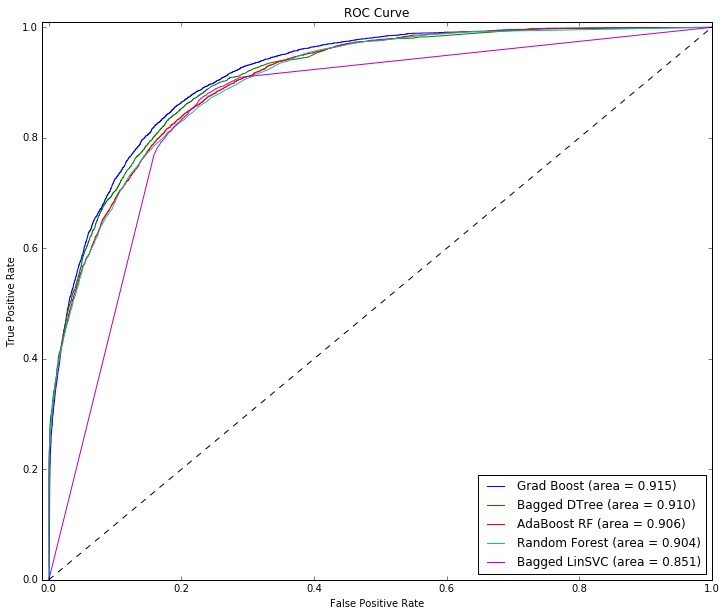

```python
Roc_Plot_Show()
```